# Relatório delegaçoes

2023-12-17

Este relatório traz os dados gerais sobre a evolução das delegações brasileiras a conferências multilaterais de meio ambiente. Em linhas gerais, trazemos os dados sobre o tamanho das delegações e sobre o perfil das delegações.

# 1 Informações básicas

## 1.1 Versão do banco

Relatório mais recente: “2023-12-17”

**Versão da planilha deleg**: 2023-11-23

**Versão da planilha orgs**: 2023-11-23

**Versão da planilha class**: 2022-06-29

**Versão da planilha eventos**: 2023-12-14

## 1.2 Correções para versões futuras

**Arrumar o tamanho do texto e a largura das figuras, que estão muito estreitas. Com essa largura, é inviável o facet de duas colunas (números de ano muito espremidos)**

## 1.3 Notas para interpretação

### 1.3.1 Processo de coleta e limitações do banco a serem levados em consideração

- A partir de 2015, os dados referentes às COPs da UNFCCC sofrem uma mudança importante: o Brasil passa a registrar os membros da delegação oriundos da sociedade civil como ‘party overflow’. Participantes nessa categoria não têm seu nome incluído nas listas oficiais de participantes, o que representa importante quebra nos nossos dados. Consequentemente, a diferença pré e pós 2015 nos dados de tamanho e, principalmente, perfil da delegação deve ser analisada com cautela.
- Ao analisar alguns dados, é importante ter em mente os critérios para atribuição da organização ao participante. Quando há mais de uma organização, por exemplo, optei por classificar com a organização de menor nível (ex.: CNI e Suzano SA, vai como Suzano). Isso pode aumentar a variedade de atores, dado que empresas e ONGs muitas vezes se organizam como redes e federações. *Valeria revisitar os critérios na construção do banco para ver se há outras questões relevantes, seja nessa etapa, seja na classificação de tipo_org (ex.: o que é um órgão de pesquisa? quando organização governamental é uma diferente e quando é reduzida ao órgão superior?)*

# 2 Preparação dos dados

## 2.1 Preparo do banco

Antes de apresentar os dados, é preciso construir o banco principal integrando os dados dos bancos parciais (eventos, delegações, indivíduos) no R. O script para isso será incluído aqui, mas rodado de forma silenciosa.

- Carregando as bases separadas

```r
## Importando os dados ------------
getlatest_file <- function(basefilename){
  list.files(pattern = paste0(basefilename, "-.+\\.csv"))
}

deleg <- read_delim(getlatest_file("deleg"),
                    ";", escape_double = FALSE,
                    col_types = cols(
                      #X1 = col_skip()
                      ),
                    #locale = locale(encoding = "ISO-8859-1"),
                    trim_ws = TRUE)

orgs <- read_delim(getlatest_file("orgs"),
                   ";", escape_double = FALSE,
                   col_types = cols(
                     #X1 = col_skip()
                     ),
                   #locale = locale(encoding = "ISO-8859-1"),
                   trim_ws = TRUE) %>% distinct()

class <- read_delim(getlatest_file("class"),
                   ";", escape_double = FALSE,
                   col_types = cols(
                     #X1 = col_skip()
                     ),
                   locale = locale(encoding = "ISO-8859-1"),
                   trim_ws = TRUE) %>% distinct()


eventos <- read_delim(getlatest_file("eventos"),
                      ";", escape_double = FALSE,
                      #locale = locale(encoding = "UTF-8"),
                      trim_ws = TRUE)
```

- Integrando as bases em uma

```r
# Criando deleg_completo (deleg+orgs+class) --------
orgs_classificado <- left_join(orgs, class) %>% select(-c(org_sujo, org_detalhe_sujo))
# N de rows aumenta, porque tem orgs que ficaram apenas na class e saíram da lista orgs (foram erros na padronização e corrigidos posteriormente)
# Teste (resultado deve ser tibble vazio): left_join(orgs, class, by = "id_org_unica") %>% filter(org_limpo.x != org_limpo.y)

deleg_completo <- deleg %>% select(-c(org, org_detalhe)) %>% left_join(orgs_classificado, by = "id_org_dupla")

# Limpando deleg_completo
deleg_completo <- deleg_completo %>% mutate(across(where(is.character), str_trim))

rm(deleg, orgs, class)
```

- Organizando a base de eventos

```r
# Limpando a base dos eventos --------

### Limpar e renomear colunas
eventos <- eventos %>% select(-c(`Código ONU`, Comentário,
                                 `Formato lista`,
                                 `Aberto?`, `Questões a atentar`,
                                 Corrigendum, Local)) %>% #retira colunas irrelevantes
  rename(#renomeia colunas
    conf = `Nome do evento`,
    conference = `Conf/Conv`,
    tema = `Regime/Tema`,
    data = Data,
    location = Locale,
    tipo_evento = `Tipo evento`,
    infMEA_list = `Lista MEA?`,
    coleta = `Coleta?`,
    proces = `Proces.?`,
    mainconf = `Principais convenções + gdes conf`
  )

eventos <- eventos %>% mutate(
  data = if_else(str_count(data)==4, #se falta o mês (só ano)
                 paste0(data, "-01"), #padroniza como janeiro
                 data)) %>%
  mutate(
    data = if_else(is.na(data)== F,
                   paste0(data, "-01"), #padroniza data no dia 1 do mês
                   data)
  ) %>% mutate(data = lubridate::ymd(data),
               ano = lubridate::year(lubridate::ymd(data)))

eventos <- eventos %>% mutate(across(where(is.character), str_trim))
```

# 3 Dados básicos sobre a participação ao longo do tempo

A base será filtrada mais adiante. [é importante retirar pós 2018, porque os pontos de 2019 e 2020 sugerem uma tendência que não existe, o que afeta a interpretação do gráfico - algo que poderia ser estabilidade será lido como queda, por exemplo]

## 3.1 Tamanho das delegações ao longo do tempo

```r
#preparar a base do tamanho deleg
deleg_evento <- left_join(deleg_completo,
                          select(eventos, c(conf, tema, ano, tipo_evento, infMEA_list)))

# identificando os eventos p/ os quais o BR nao enviou delegação:
eventos_semdeleg <- tibble(conf = setdiff(eventos[eventos$coleta=="Sim" & !is.na(eventos$coleta),]$conf, unique(deleg_completo$conf))) %>%
  left_join(eventos) %>%
  mutate(count = 0)

# contagem de tamanho da delegação, incluindo eventos acima como deleg_size = 0
deleg_size <- deleg_evento %>% group_by(conf, ano) %>% summarize(count = n()) %>%
  bind_rows(select(eventos_semdeleg, c(conf, ano, count)))

# filtrando apenas delegações entre 1970 e 2018
eventos_filtrados <- eventos %>% filter(ano >= 1970 & ano <=2018) %>% pull(conf)
deleg_evento <- filter(deleg_evento, conf %in% eventos_filtrados)
deleg_size <- filter(deleg_size, conf %in% eventos_filtrados)
deleg_completo <- filter(deleg_completo, conf %in% eventos_filtrados)


stats_deleg <- deleg_size %>% group_by(ano) %>%
  summarise(deleg_media = mean(count),
            deleg_mediana = mean(count),
            sd_deleg_size = sd(count),
            n_events = n()
            )
```

### 3.1.1 Medidas resumo do crescimento da delegação brasileira ao longo do tempo

[Talvez valesse calcular algumas medidas básicas também: crescimento médio/ano etc]

A medida mais simples para compreender o crescimento das delegações ao longo do tempo é o tamanho médio das delegações por ano.

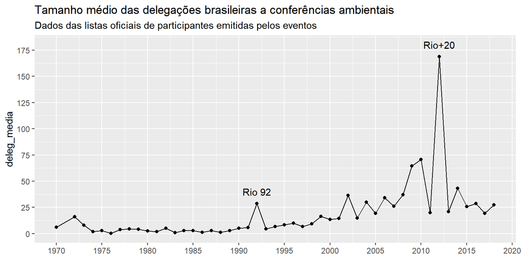

Como usamos a média, é importante observar também a variabilidade dos dados.

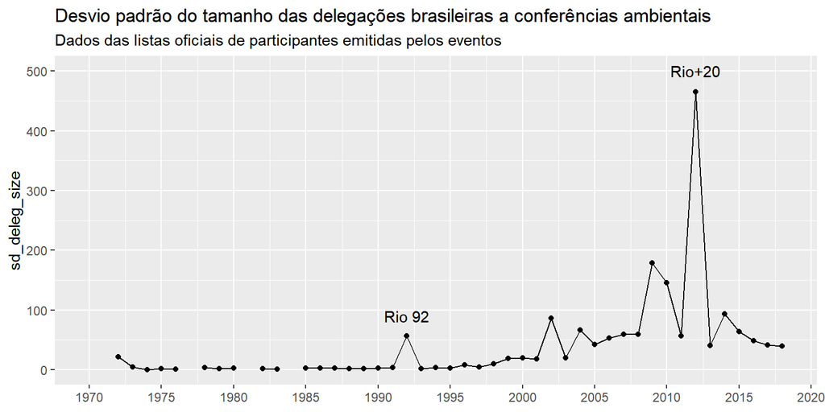

Vejamos também a média e o desvio padrão para cada década:

| decade | n_events | mean | sd | pctile75 | pctile90 | max |
| --- | --- | --- | --- | --- | --- | --- |
| 70s | 19 | 4.947368 | 6.899869 | 5.50 | 7.8 | 31 |
| 80s | 32 | 2.375000 | 2.059596 | 3.25 | 5.9 | 7 |
| 90s | 70 | 10.128571 | 19.529184 | 8.00 | 14.0 | 157 |
| 00s | 89 | 29.988764 | 76.461145 | 11.00 | 71.4 | 572 |
| 10s | 93 | 45.354839 | 165.759952 | 10.00 | 115.2 | 1490 |

E por tema.

```r
deleg_size %>% left_join(eventos %>% select(c(conf, tema))) %>%
  group_by(tema) %>% summarise(mean = mean(count), sd = sd(count)) %>%
  knitr::kable("simple")
```

| tema | mean | sd |
| --- | --- | --- |
| Biodiversidade - CBD | 42.578947 | 49.689386 |
| Biodiversidade - Espécies | 4.200000 | 3.926406 |
| Biodiversidade - Plantas | 4.320000 | 2.764658 |
| Biodiversidade - UNESCO | 2.000000 | 1.632993 |
| Clima | 96.108108 | 127.073422 |
| Desertificação | 12.187500 | 12.416219 |
| Florestas | 4.763158 | 3.131654 |
| Governança ambiental | 4.500000 | 1.643168 |
| Grandes conferências ONU | 172.500000 | 423.903184 |
| Lixo tóxico e químicos | 7.914286 | 4.616922 |
| Oceano | 5.358974 | 1.979994 |
| Ozônio | 5.097561 | 2.643907 |

Vemos que há uma diferença clara entre um grupo de temas (CBD, Clima, Gdes conferências ONU) e os demais no tamanho das delegações. Vejamos a diferença e, em seguida, o detalhamento por década para os temas ‘menores’

```r
deleg_size %>% left_join(eventos %>% select(c(conf, tema))) %>%
  mutate(gdestemas = if_else(
    tema %in% c("Biodiversidade - CBD", "Clima",
                "Grandes conferências ONU"),
    "Temas destaque", "Temas menores")
    ) %>% group_by(gdestemas) %>%
  summarise(n_events = n(), mean = mean(count), sd = sd(count),
            pctile75 = quantile(count, 0.75) %>% unname(),
            pctile90 = quantile(count, 0.9) %>% unname(),
            max = max(count)
            ) %>%
              knitr::kable("simple")
```

| gdestemas | n_events | mean | sd | pctile75 | pctile90 | max |
| --- | --- | --- | --- | --- | --- | --- |
| Temas destaque | 68 | 94.63235 | 201.735523 | 120.0 | 210 | 1490 |
| Temas menores | 235 | 5.66383 | 4.877317 | 7.5 | 10 | 55 |

```r
deleg_size %>% left_join(eventos %>% select(c(conf, tema))) %>%
  filter(!tema %in% c("Biodiversidade - CBD", "Clima",
                       "Grandes conferências ONU")) %>%
  mutate(decade = cut(ano, breaks = c(1970, 1979, 1989, 1999, 2009, 2019),
               include.lowest = T,
               labels = c("70s","80s","90s","00s","10s"),
               ordered_result = TRUE)) %>%
  group_by(decade) %>% summarise(mean = mean(count), sd = sd(count)) %>%
  knitr::kable("simple", caption = "Apenas conferências dos temas menores")
```

Apenas conferências dos temas menores

| decade | mean | sd |
| --- | --- | --- |
| 70s | 3.352941 | 2.892689 |
| 80s | 2.387097 | 2.092485 |
| 90s | 6.487805 | 8.176558 |
| 00s | 6.457143 | 3.701491 |
| 10s | 6.342105 | 3.917661 |

#### 3.1.1.1 Distribuição da variável

Os dados acima sugerem que as delegações são, em sua grande maioria, pequenas, havendo apenas um número reduzido de eventos com delegações grandes. Vejamos como a variável deleg_size está distribuída.

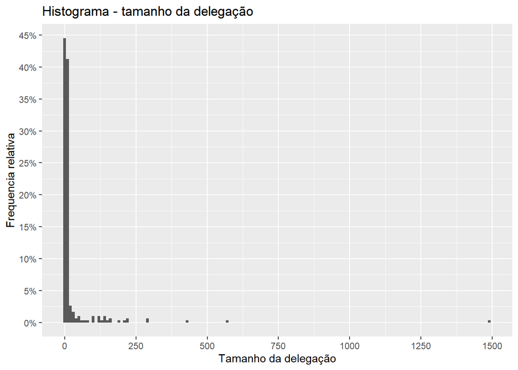

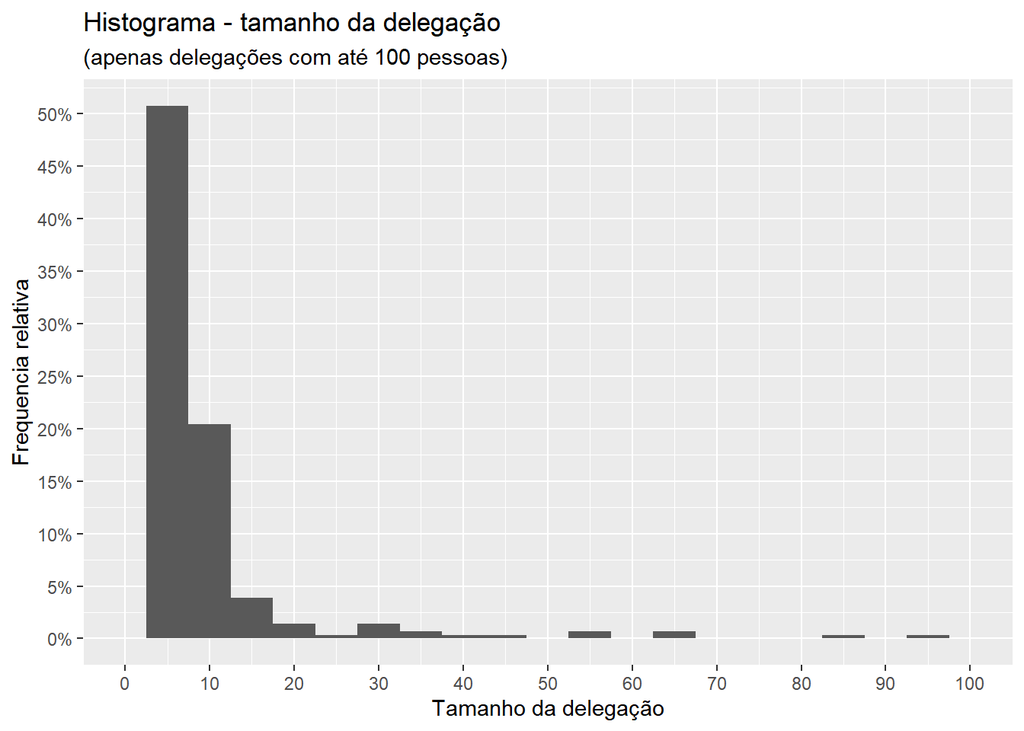

Quantis e valores de corte

|  | x |
| --- | --- |
| 50% | 6.00 |
| 70% | 8.00 |
| 80% | 10.00 |
| 90% | 32.60 |
| 95% | 126.60 |
| 99% | 293.84 |
| 100% | 1490.00 |

Vemos que mais de 50% das delegações têm até 6 membros. Se chegamos a 10, esse percentual já chega a 80%. Apenas o top 10% de tamanho têm mais de 30 (sendo 303 o total de delegações, isso significa cerca de 30! - são 34 eventos com 30 ou mais)

As medidas-resumo permitem ver a tendência, mas ainda escondem a variação e a quantidade de dados por trás da medida. Para visualizar esses pontos, recorremos aos gráficos de dispersão.

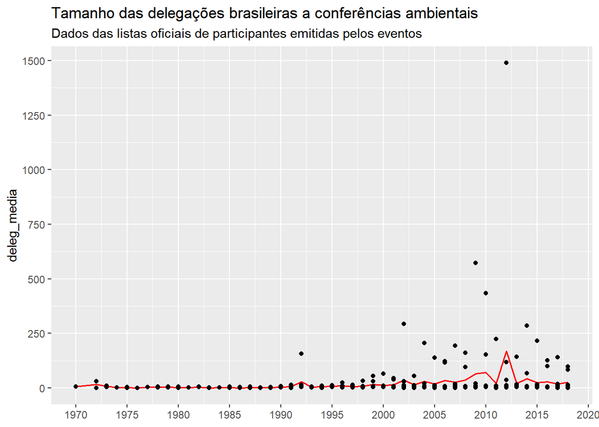

Como se vê, a variação a partir dos anos 2000 é muito maior. A média (linha vermelha) não parece uma descrição muito boa dos dados.

### 3.1.2 Desagregando as delegações: gráficos de dispersão

No gráfico de dispersão abaixo, cada círculo corresponde a um evento. Cores variam conforme o tema do evento, e eventos ocorridos no Brasil foram marcados com um triângulo.

```r
deleg_size <- deleg_size %>%
  left_join(select(eventos, c(conf, location, tema))) %>%
  mutate(
    Local = if_else(str_detect(location, "Brazil"),
                    "Brasil", "Fora do Brasil/Sem info"),
    Tema = if_else(tema != "Clima" & tema != "Grandes conferências ONU",
                   "Outros", tema)
    ) %>%
  mutate(
    Local = if_else(is.na(Local), "Fora do Brasil/Sem info", Local),
    Tema = if_else(tema == "Grandes conferências ONU",
                   "Des. Sustentável", Tema)
    )
```

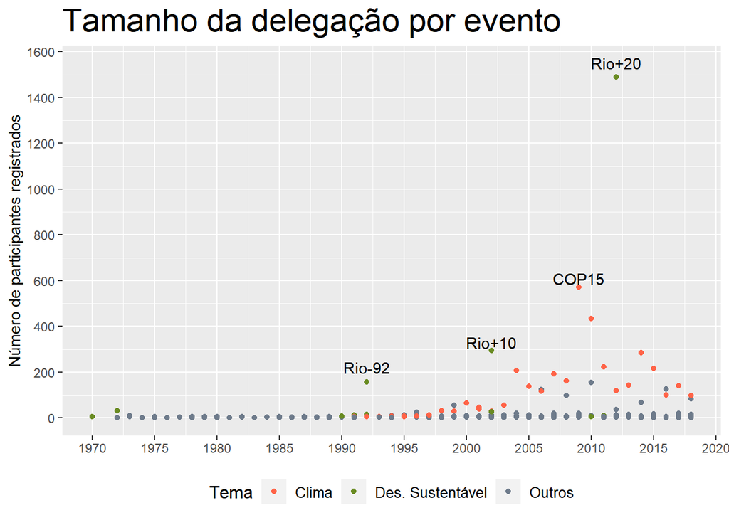

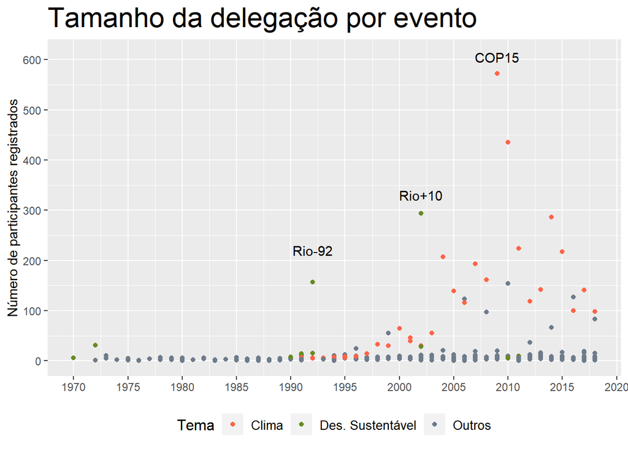

A figura mostra claramente que as conferências de clima apresentam uma tendência de ascensão nos anos 90 e 2000, seguida de uma queda acentuada pós 2009 (COP15). Após 2015, parece haver estabilidade em um novo patamar, acima do observado em décadas anteriores. A participação nas conferências de desenvolvimento sustentável da ONU (Estocolmo 72, Rio 92, Joanesburgo 2002, Rio 2012) costuma ser muito mais alta do que a nas demais conferências do período. Embora Estocolmo tenha uma delegação grande se comparada com as enviadas para os demais eventos do período (31 pessoas), trata-se de uma delegação pequena para o padrão das conferências de desenvolvimento sustentável pós 92. Note-se que há alguns eventos em verde, portanto de desenvolvimento sustentável, com delegações pequenas já depois de 90 - trata-se, aqui, das PrepComs para as grandes conferências. É esperado que a delegação nesse tipo de evento seja menor, como exploraremos mais adiante.

*Nota: no site da ONU são elencadas algumas outras conferências multilaterais sobre desenvolvimento sustentável, que não foram incluídas na base. Ex.: UNGASS-19 (uma sessão especial da AG-ONU em 97, chamada de Rio+5); Cúpula de Desenvolvimento SUstentável da ONU em 2015; Como resultado das conferências, foram também criados alguns fóruns sobre o tema - alguns incluídos no tema ‘Governança ambiental’, outros não. É possível que a ausência desses eventos na base infle o tema desenvolvimento sustentável - efetivamente, originalmente a categoria que destacamos no gráfico era chamada de “Grandes conferências ONU” na base.*

[se julgar interessante, dar precisão a esses dados e à diferença - Estocolomo é x vezes maior que a média da década de 70 (sem unche), etc]

### 3.1.3 Observando mais a fundo os temas de menor destaque

Vejamos se, ao retirar os eventos de clima e as grandes conferências de desenvolvimento sustentável, podemos discernir algum padrão nas delegações dos temas de menor visibilidade.

O primeiro gráfico mostra apenas as conferências de biodiversidade, que apresentam um patamar de participação superior aos demais temas. Para todo o período, **a delegação média nas conferências de biodiversidade é de 13.1898734**. Se observarmos apenas os eventos da **CDB, 42.5789474**

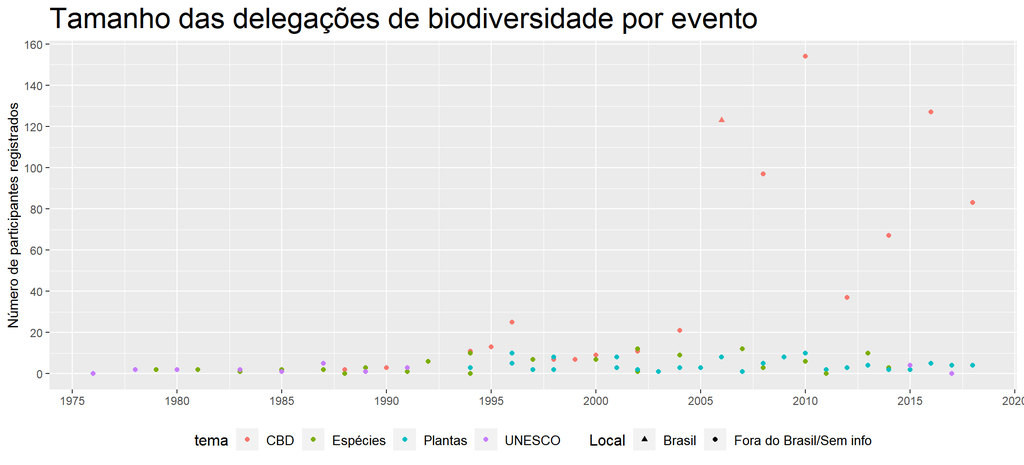

Vemos que a CBD claramente tem um patamar de participação mais elevado que os demais eventos de biodiversidade, cujas delegações seguem o padrão das conferências mais “técnicas” - raramente passando dos 10 delegados. Houve um grande crescimento das delegações à CBD ao compararmos a década de 90 e 2000 (nos 90, a delegação média é de 9.8571429; nos 2000 45; na década de 2010, 93.6). Essa evolução é semelhante à observada na arena de clima, mas aparece de forma menos clara (e menos intensa) em biodiversidade. A variação entre eventos é maior na CBD, o que provavelmente reflete seu caráter bianual (ao invés de anual, como na UNFCCC) e a maior dificuldade de manter a visibilidade do tema.

Observemos, agora, as delegações aos eventos com outros temas:

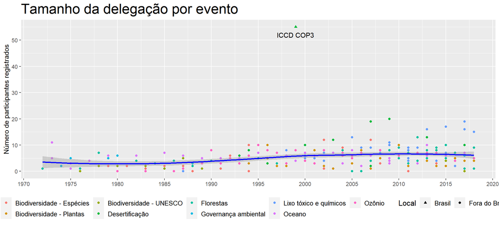

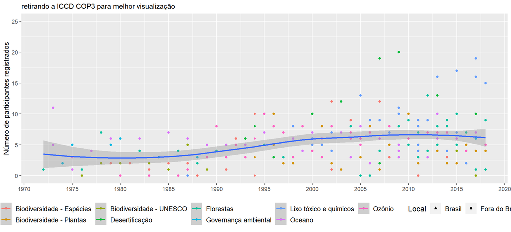

Vemos que, à exceção de Clima, Biodiversidade, e das grandes Conferências de Desenvolvimento Sustentável, os temas seguem praticamente a mesma tendência. Há relativa estabilidade, com um número baixo de participantes por delegação. A única exceção foi a 3ª COP da Convenção de Desertificação, realizada em Recife em 1999, para a qual o Brasil enviou 55 representantes. Se observamos a linha de tendência (uma loess), vemos que houve um leve aumento no tamanho da delegação a partir da segunda metade dos 90 e, especialmente, dos anos 2000.

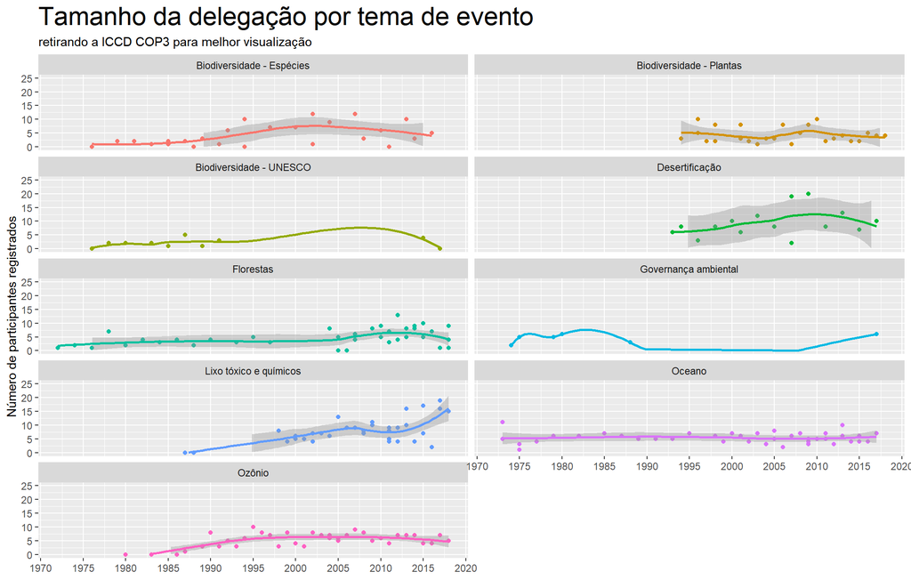

Apesar do número reduzido de observações em alguns temas, vemos uma leve tendência de crescimento na participação nas áreas de Ozônio e de Lixo Tóxico e Químicos. Nos demais casos, a julgar por nossos dados, a variação não parece ser significativa o suficiente para ser caracterizada como uma tendência.

### 3.1.4 Dividindo os tipos de conferência

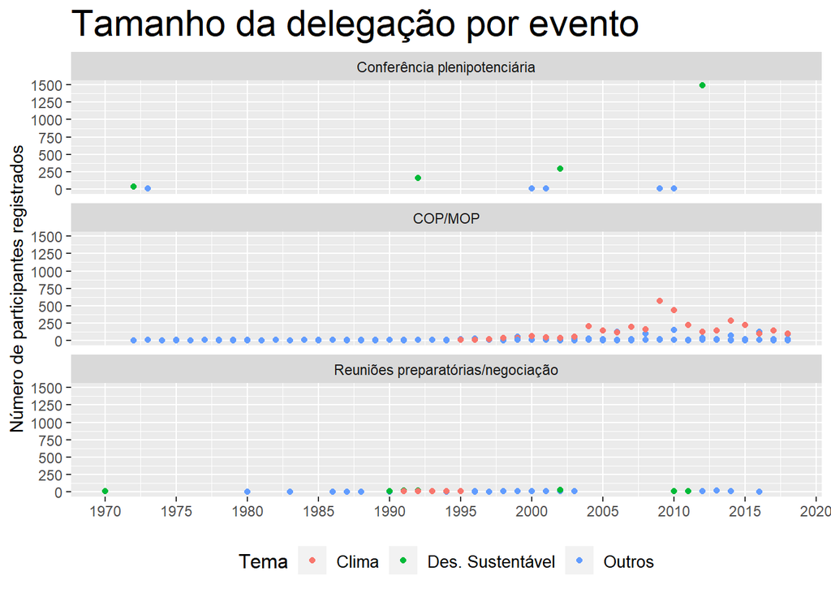

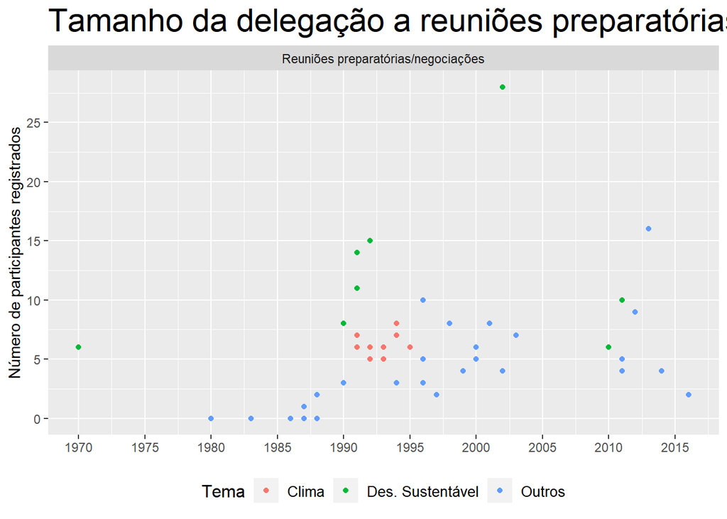

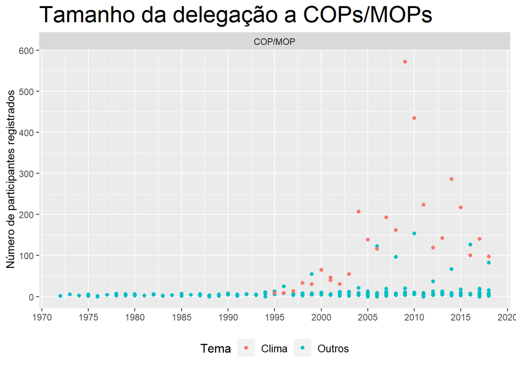

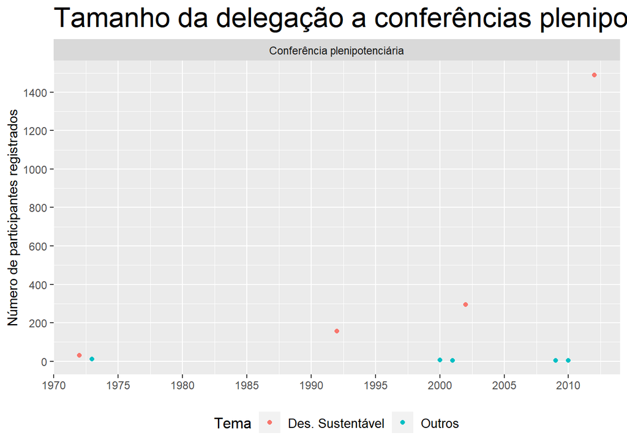

# 4 Perfil das delegações ao longo do tempo

## 4.1 Número e diversidade de organizações

Os dados sobre o número e tipo das organizações participantes (sem olhar para a quantidade de indivíduos pertencentes à organização) nos dão uma primeira noção sobre a *diversidade* das delegações brasileiras. Quanto mais organizações presentes – e quanto mais diversas entre si as organizações, ie, orgs de diferentes “tipos” – podemos dizer que mais diversa é a delegação brasileira no sentido de incluir atores distintos. Evidentemente, é preciso levar em conta também a diferença no espaço dado a essas organizações, o que será avaliado mais adiante (e qualitativamente na pesquisa)

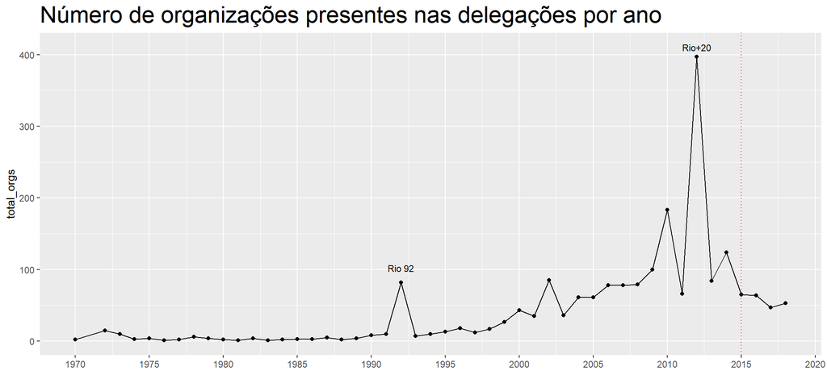

**Cálculos pontuais para o artigo** - Média de n orgs pós 2015 (incluso): 57.25

- Média de n orgs por tema (desconsidera anos em que nao há orgs, ie, nao ha evento no tema):

| tema | mean |
| --- | --- |
| Biodiversidade - CBD | 17.588235 |
| Biodiversidade - Espécies | 2.684210 |
| Biodiversidade - Plantas | 2.363636 |
| Biodiversidade - UNESCO | 1.125000 |
| Clima | 41.535714 |
| Desertificação | 4.133333 |
| Florestas | 2.769231 |
| Governança ambiental | 1.833333 |
| Grandes conferências ONU | 60.444444 |
| Lixo tóxico e químicos | 7.800000 |
| Oceano | 3.483871 |
| Ozônio | 3.903226 |

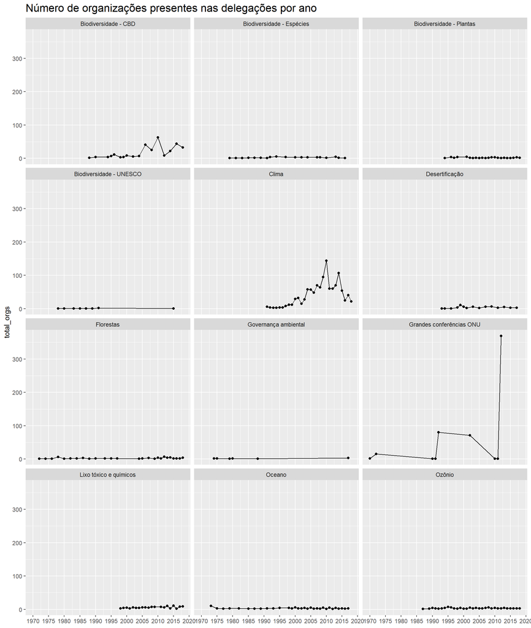

Olhando os gráficos acima, notamos que o crescimento no número de organizações é praticamente todo derivado das conferências de clima. As grandes conferências de desenvolvimento sustentável da ONU também têm impacto relevante, mas ocorrem de maneira mais espaçada, gerando picos importantes - em particular, o da Rio+20.

O número de organizações presentes na Rio+20 é claramente um outlier que dificulta a visualização das tendências nos demais temas. Enquanto em clima, o tema com maior número de organizações, vemos um pico da ordem de 100 atores, a Rio+20 registra em torno de 400. Para melhor observar a variação nos demais temas, geramos um gráfico sem as conferências de desenvolvimento sustentável.

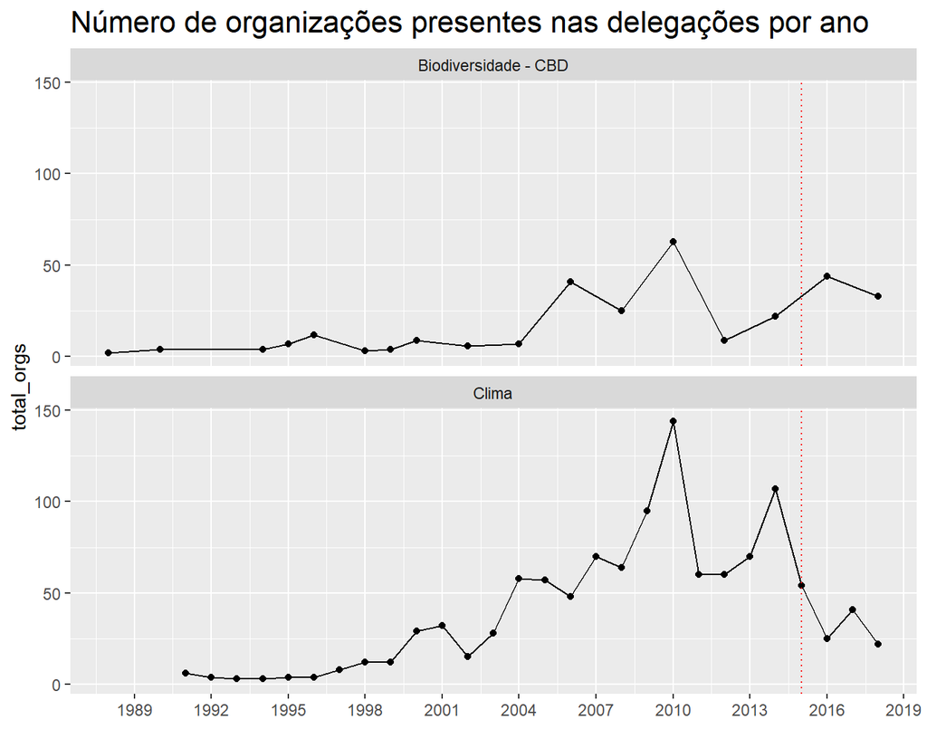

A dinâmica no número de organizações distintas na delegação é similar, mas levemente distinta da observada no tamanho das delegações. Em clima, vemos dinâmica similar de crescimento seguido de queda no início da década de 2010, com um repique posterior. Há, porém, algumas diferenças. O pico no número de organizações é 2010, não 2009, como em deleg_size. Em seguida, temos uma queda, e a diversidade volta a crescer em 2013, atingindo o pico em 2014 (pré-Paris). De Paris em diante, temos uma grande queda - **essa queda é, no entanto, artificial**: de Paris em diante, a sociedade civil passa a ser classificada como party overflow, saindo das listas de participantes. Em biodiversidade, **o número de organizações cresce significativamente na segunda metade dos 2000**. Essa é a mesma dinâmica observada no tamanho da delegação à CBD. O gráfico tem leitura prejudicada pela grande variação entre os anos – isso decorre do fato de as COPs da CDB serem (modo geral) bianuais. Em anos ímpares, os pontos refletem as convenções da International Plant Convention, uma convenção de muito menor visibilidade e reuniões menores.

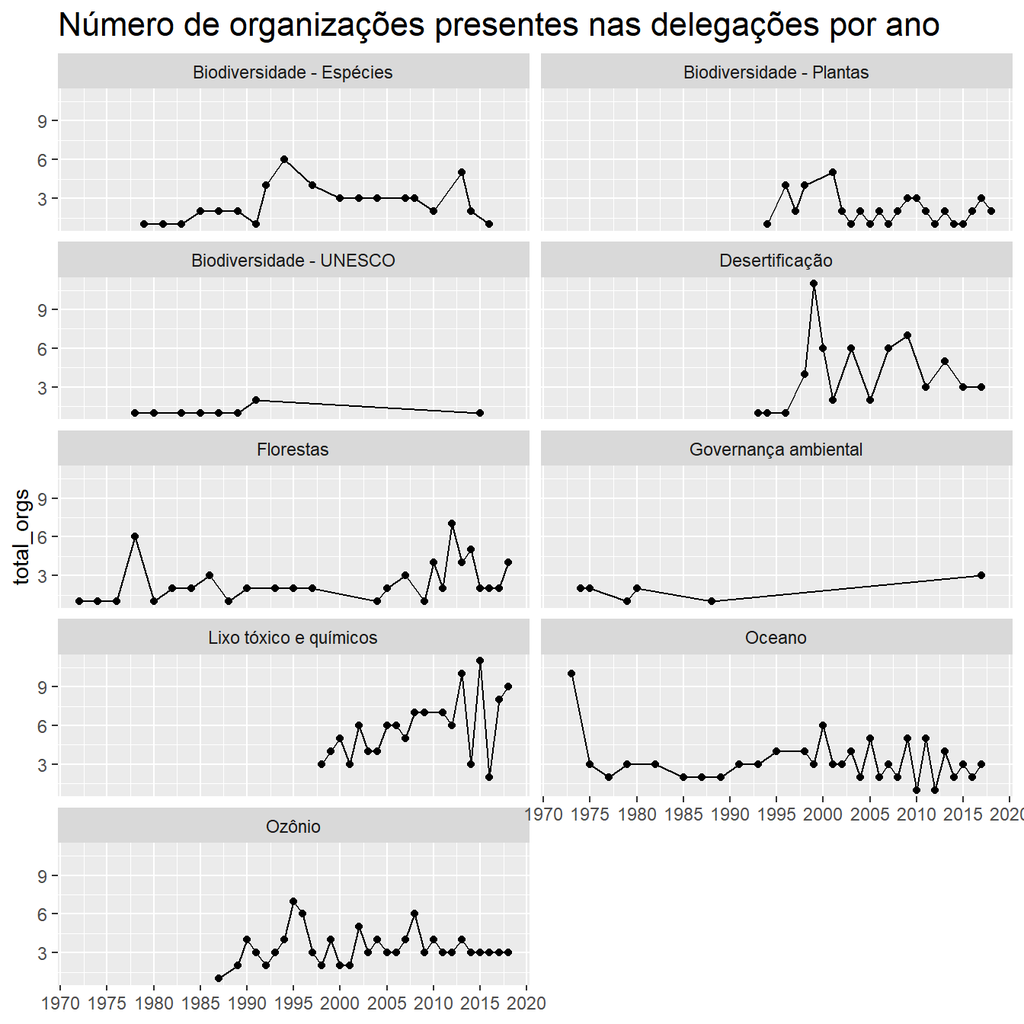

[ver o máximo e calcular a média!]

O impulso no número de organizações é, portanto, uma tendência restrita à área de clima, o que sugere uma atenção especial ao tema na pesquisa.

### 4.1.1 Evolução do número de organizações por tipo

Vale a pena observar se há diferença na tendência de evolução a depender do tipo de organização. Na figura abaixo, eliminamos o MRE e o Legislativo, por terem um número quase constante (MRE é sempre 1, Legislativo, no máximo 2). Também foram excluídas as organizaçoes da categoria residual “Outros”, de número reduzido, e “Sem informação” (uma única “organização”, também constante).

*[talvez valesse a pena refazer os cálculos de modo a manter os anos nos quais não ocorrem reuniões do tema como NA - estão como delegação vazia aqui, e isso pode induzir a interpretações equivocadas (a linha, por exemplo, fica mais errática quando nao precisaria ser assim)]*

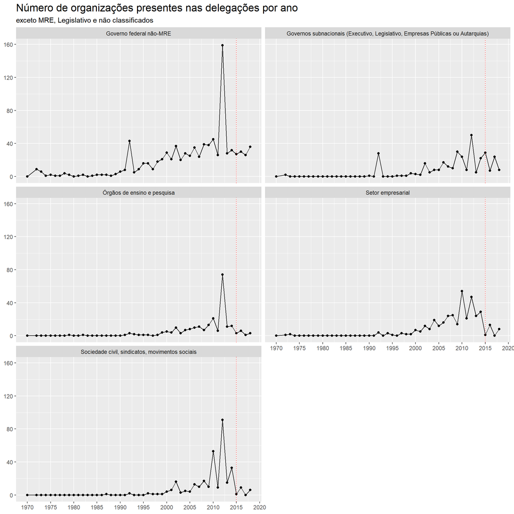

## 4.2 Número e diversidade de indivíduos

[Pra fazer esse, é preciso importar a planilha de individuos]

## 4.3 Participação do MRE nas delegações

[nesse trecho, valeria refinar essa questão do tamanho da delegação. não dá pra ver tão bem no gráfico as diferenças, só as gigantes]

### 4.3.1 Parcela do MRE no total das delegações

```r
MRE_conf <- deleg_evento %>% group_by(conf, ano, tipo_org_reduzido) %>%
  summarise(count = n()) %>%
  ungroup %>%
  complete(tipo_org_reduzido, nesting(conf, ano),
           fill = list(count = 0)) %>%
  group_by(conf) %>%
  mutate(deleg_size = sum(count),
         percentual = count/sum(count)) %>% ungroup()

#retirar eventos com 100% nao identificado
MRE_conf[MRE_conf$tipo_org_reduzido == "Não identificado" & MRE_conf$percentual == 1,]$conf -> eventosexcl

MRE_conf <- MRE_conf %>% filter(! conf %in% eventosexcl) %>%
  filter(tipo_org_reduzido == "Governo federal MRE") %>%
  left_join(select(eventos, c(conf, location, tema, tipo_evento))) %>%
  mutate(Local = if_else(str_detect(location, "Brazil"), "Brasil", "Fora do Brasil"),
         Tema = case_when (
           tema == "Clima" ~ "Clima",
           tema == "Grandes conferências ONU" ~ "Des. Sustentável",
           str_detect(tema, "Biodiversidade - CBD") ~ "Biodiversidade",
           tema != "Clima" & tema != "Grandes conferências ONU" & #tema != "Florestas" ~ "Outros"
             tema != "Biodiversidade" ~ "Outros"
         )
         )
```

Abaixo vemos como o % do MRE na delegação muda ao longo do tempo. A figura abaixo mostra como, a partir dos anos 90, as delegações passam a ter menor concentração do MRE - os pontos passam a se concentrar mais na parte inferior do gráfico.

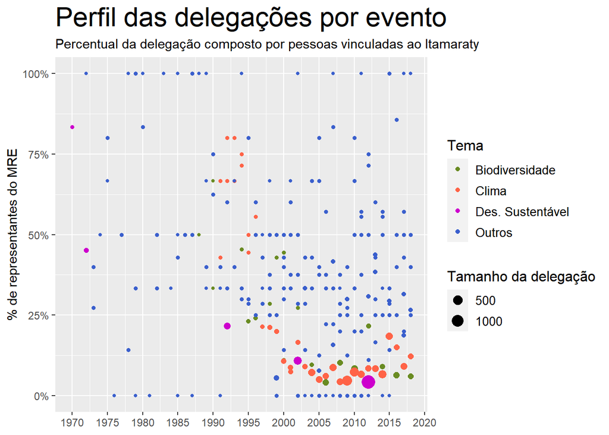

Para facilitar a visualização dessas tendências e das diferenças entre temas, acrescentamos ao gráfico linhas de regressão loess para cada tema.

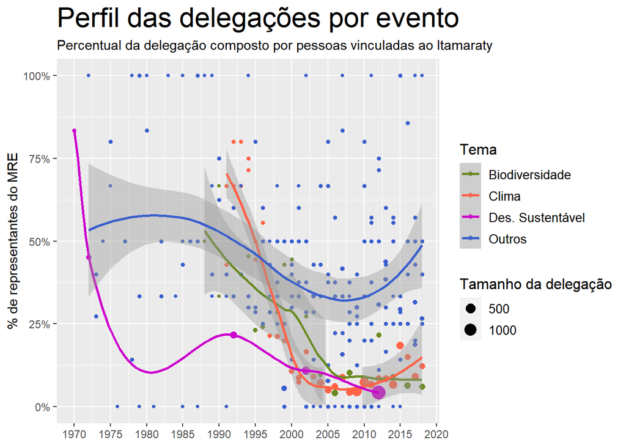

Nota-se que, para os três temas destacados, a participação relativa do MRE caiu vertiginosamente.